# College Score Card Ranking

## **Introduction**

#### College Score Card Ranking is a College-Recommendation Program by Python

[figure not shown]

## Our Mission

#### Students with different backgrounds have different needs and concerns about college requirements. We categorize three major groups of prospective students: International, local and transfer students, and we will evaluate different factors based on each group?s needs.

## Summary Of Research Questions:

- How should we come out with different solutions that can help different types of students (Ex: internaxtional students, local students, transfer students) to find the colleges that suit them most by applying the dataset?
- How can the different factors (like academic rank, tuition fee) be used together within different influence score to come out a total rank of a school?
- We can also predict a college’s future acceptance rate to predict collecting the previous year’s data (from 1996 - 2014) and find functions to describe the relationships between those data. Is there any way to analyze the trend of acceptance rate of a college so that the students have a better idea of which colleges to go?

## Dataset

> We collected our dataset from *data.gov*

[Dataset Download Here](https://catalog.data.gov/dataset/college-scorecard/resource/b8f3d10b-0974-40db-b5fa-3c87ecae516b)

## Methodology

#### **User Inputs**

> We designed our input panel into two parts: **Recommendation Panel** & **Acceptance Rate Panel**

#### 1. College Recommendation Panel

```
a. Describe your student status: International/Local/Transfer?

b. Enter your SAT Score:

c. Enter your expected Maximum Tuition(per quarter)?
```

#### Influence score is the **key** for our recommendation-program.

#### influence score for each filtered college information will be calculated based on different factors of interest, and the calculation is different for International, local and transfer students.

##### Groups of interest: (*Note: influence score for each college is a single value. It starts from 0; it evaluates and sums up the weight of each factor)

#### Methodology:

1. International Students:

- ```
  Tuition: 15%
  ```

- ```
  Ranking: 20%
  ```

- ```
  Acceptance Rate: 35%
  ```

2. Local Students:

- ```
  Tuition: 20%
  ```

- ```
  Debt: 10%
  ```

- ```
  Gender Ratio: 10%
  ```

- ```
  SAT: 25%
  ```

- ```
  Acceptance Rate: 35%
  ```

3. Transfer Students:

- ```
  Acceptance Rate: 40%
  ```

- ```
  Tuition: 30%
  ```

- ```
  SAT: 10%
  ```

- ```
  Ranking: 20%
  ```

#### Project Challenges

Let’s take a glance of our original data:

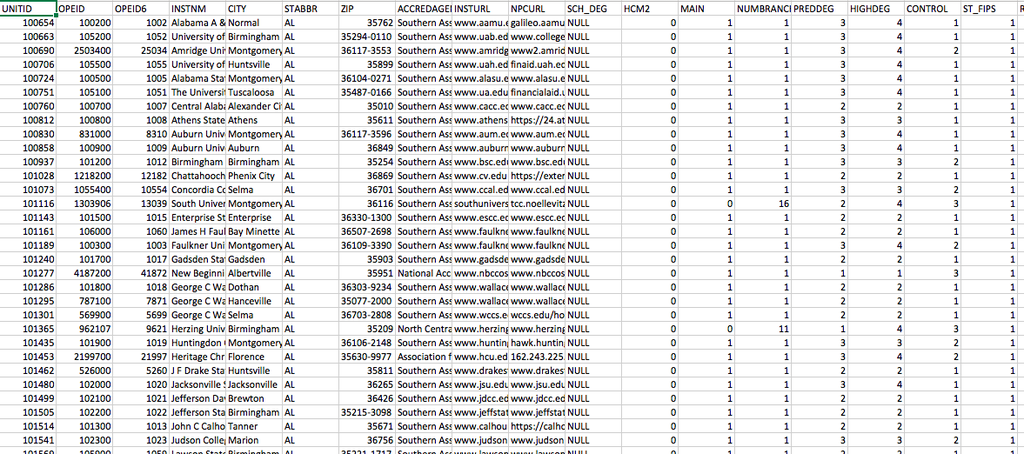

Since the data are extracted directly from the system, we can see the column names are unorganized, and there are a large amount of *NULL*s, which made us hard to filter and re-organize the dataset

#### Panel Instruction

Please View Instruction - [Here](https://youtu.be/S1rcbpwc8S0)

#### Results Present

> College Recommendation

```
a) International
b) Local
c) Tranfer:
? (Please Type a, b, c):
b
please input your sat score:2000
please input your maximum tuition you can accept:8000
```

```
1. Brigham Young University-Idaho
score: 0.780645154651
city:Rexburg    state:ID    rank:314    tuition:3850.0  sat:1036.0  AC:0.996263079223   debt:5750.0 Mal:0.4253

2. Southern University at New Orleans
score: 0.660160232884
city:New Orleans    state:LA    rank:1428   tuition:4911.0  sat:808.0   AC:0.488803582853   debt:14250.0    Mal:0.2503

3. Alcorn State University
score: 0.654914321391
city:Alcorn State   state:MS    rank:1037   tuition:6108.0  sat:851.0   AC:0.829139072848   debt:16000.0    Mal:0.3541
```

> College Acceptance Rate Trend (2004 - 2013)

```
Recommend College OR Check Accept Rate? Enter R or A or Exit: A
Enter a University Name(Full Name):Cornell University
```

- Cornell University

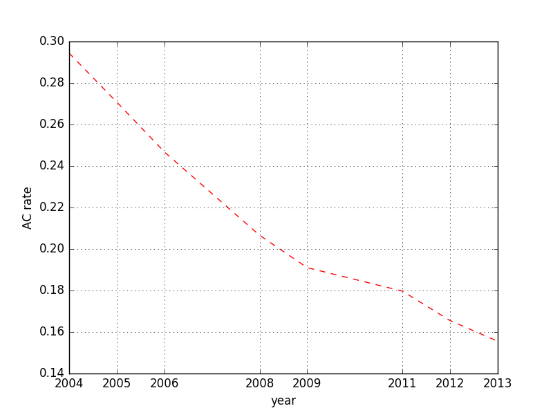

```
Recommend College OR Check Accept Rate? Enter R or A or Exit: A
Enter a University Name(Full Name): New York University
```

- New York University

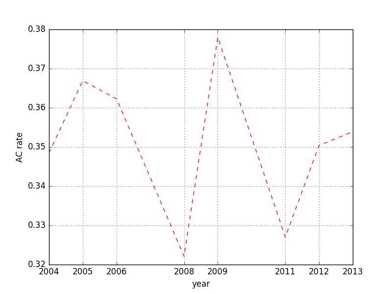